# **Analyzing hate crimes in USA between 1991 and 2020**

Diana Najjuma

05-01-2023

# Introduction

Incidents of hate crimes have been on the rise in the United States. The offenders who commit such heinous crimes have different motivations; sometimes they are motivated by religious discrimination, sometimes racial discrimination and sometimes from their hatred against people of different sexual orientations.

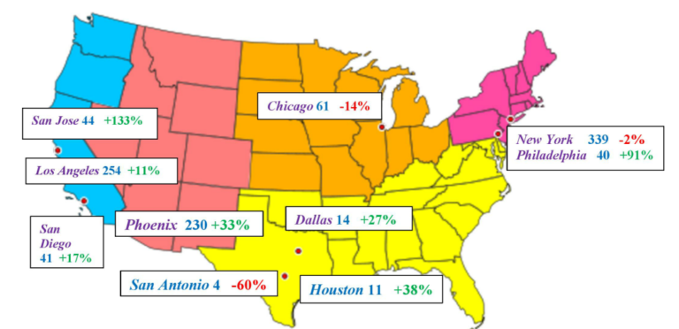

Hate Crime in Largest U.S. Cities Rise 12% in Over a Decade!

# Definition of a Hate Crime

A hate crime is any criminal act or attempted criminal act directed against a person or persons based on the victim’s actual or perceived race, nationality, religion, sexual orientation, disability or gender.

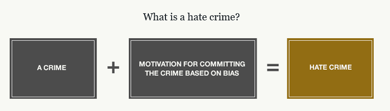

The “crime” in hate crime is often a violent crime, such as assault, murder, arson, vandalism, or threats to commit such crimes. It may also cover conspiring or asking another person to commit such crimes, even if the crime was never carried out.

# Definition of a Hate Crime

Examples of hate crimes include when:

- Someone destroys property with things that insult the victim. For example, someone vandalizes a gay couple’s property by spray painting homophobic slurs across their garage door.
- Someone hurts a victim while using insults about the victim. For example, a black man was attacked and beaten up by a group of white teenagers yelling racial slurs.
- Someone forces a person to take off clothes that are part of their faith. For example, someone physically forced or threatened to beat up/rape/shoot a victim if they didn’t take off a head covering that is part of their faith.

Hate crimes may have consequences far beyond the criminal act itself. Becoming the victim of a crime is traumatic, but if the act was committed because of who you are or what you believe, the violation is even more hurtful and may cause deep emotional impacts.

# About Dataset

After searching through a variety of data sets available on the internet, I decided to use FBI Hate Crime Statistics found on **FBI’s Crime Data Explorer (CDE) website** This data set provides information about differing hate crime incidents from 1991 to 2020.

The Hate Crime data is an FBI data set that is part of the annual Uniform Crime Reporting (UCR) Program data and contains information about hate crimes reported in the United States.

I chose this data set particularly because I am interested in crime incidents in the USA over time.

# About Dataset

The Dataset contains 219,577 observations and 28 variables

Among the variables include,

- The date of the crime
- What kind of crime it was
- The bias motivation for each of these crimes
- The offenders race
- The victim’s race
- Victim counts (if the victim was a minor or adult),
- What state and city the crime occurred in, and so on.

# Data Collection

Law enforcement agencies across USA voluntarily submit crime data to the UCR Program. Currently, as many as 18,000 agencies submit data.

The types of hate crimes reported to the FBI are then broken down by specific categories. The aggregate hate crime data collected for each incident includes the following:

# Data Collection

**Bias Motivation**: Incidents may include one or more offense types. Up to five bias motivation types can be reported per offense. The FBI collects information about single-bias incidents (crimes motivated by one type of bias) and multiple-bias incidents (offenses motivated by two or more biases.)

**Victims**: The types of victims collected for hate crime incidents include individuals (adults and juveniles), businesses, institutions, FBI may also include the number of victims under the age of 18.

**Offenders**: The collection includes the number of offenders (adults and juveniles), and when possible, the race and ethnicity of the offender or offenders. In the data collection, the term “known offender” does not imply the suspect’s identity is known, but rather some aspect of the offender is known, such as the offender’s age or gender.

**Location Type**: One of 46 location types can be designated as the location, such as house of worship, sidewalk, home, school, or unknown.

# Reading and cleaning of the Dataset

Since i worked with a very big data set, I had to remove some variables which didn’t really have any use in my investigations.

Some variables had to be given new names. For example, some variable names from the original data set did not adhere to my preferred naming conventions, and thus i had to rename specific variables using the rename function from the dplyr package.

# Questions to be investigated:

For this project, I came up with the following questions:

1. What are the most frequently committed hate crimes in USA between 1991 and 2020
2. What is the largest bias incident victim category in USA throughout 1991-2020?
3. Did Covid-19 lead to an Increase in Hate Crimes towards the Asian community in the USA?

# Frequency of crime

**1. What are the most frequently committed hate crimes in USA throughout 1991-2020?**

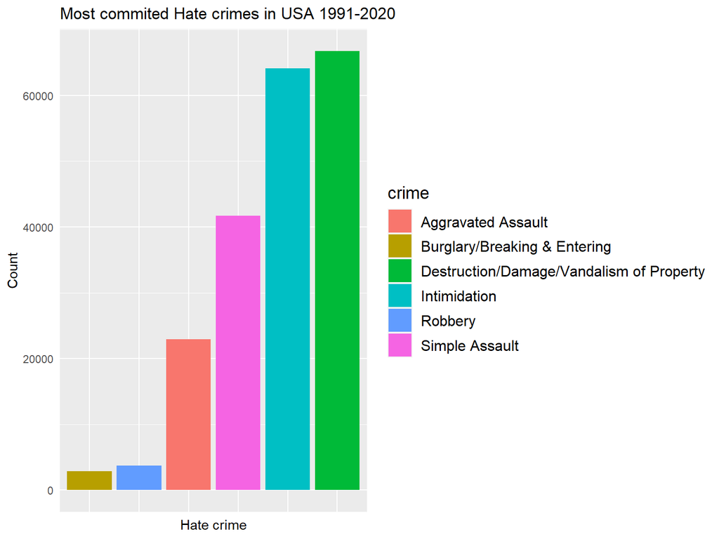

From the gragh above, we can see the Most of the hate crime offenses were crimes against property which is destruction/damage/vandalism

# 2. What is the largest bias incident victim category in the U.S.?

Incidents that are investigated and are confirmed to have a bias motivation are categorized with the appropriate bias category. Incidents can have more than one bias motivation.

- Gender Identity: Anti-Gender Non-Conforming or Anti-Transgender
- Race/Ethnicity: Anti-Arab; Anti-Asian; Anti-Black or African American; Anti-Hispanic or Latino; Anti-Asian
- Religion: Anti-Atheism; Anti-Buddhist; Anti-Catholic; Anti-Hindu; Anti-Islam (Muslim); Anti-Jehovah’s Witness
- Sexual Orientation: Anti-Bisexual; Anti-Gay (Male); Anti-Lesbian (Female); or Anti-Lesbian Gay, Bisexual, or Transgender

# 2. What is the largest bias incident victim category in the U.S.?

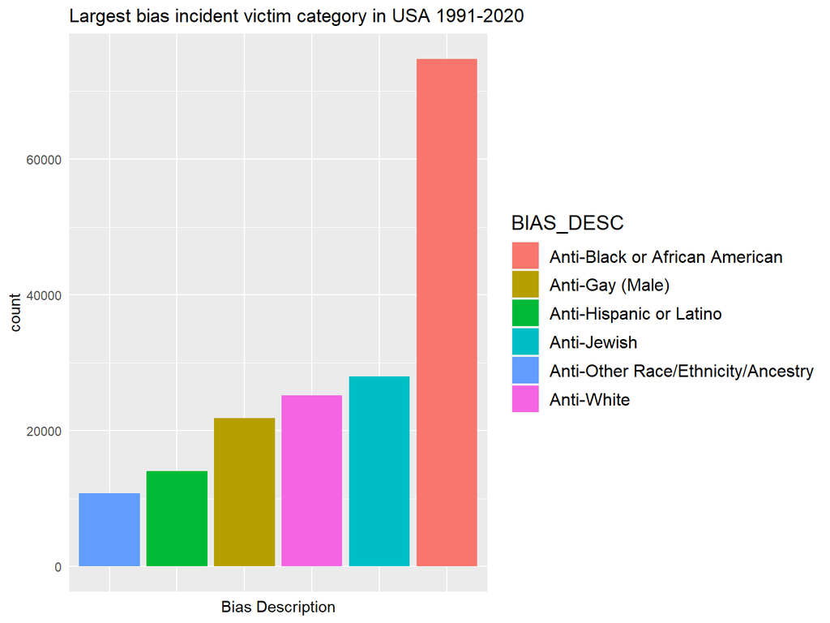

# 2. What is the largest bias incident victim category in the U.S.?

[figure not shown]

DarQuan Jones (right) was brutally beaten by white men in May 2020 in a racially motivated attack in Des Moines, Iowa.

# My next challenge:

[figure not shown]

My next challange